# Overview

Dataset info

| Number of variables | 22 |
| --- | --- |
| Number of observations | 41188 |
| Total Missing (%) | 3.9% |
| Total size in memory | 5.5 MiB |
| Average record size in memory | 141.0 B |

Variables types

| Numeric | 11 |
| --- | --- |
| Categorical | 5 |
| Boolean | 4 |
| Date | 0 |
| Text (Unique) | 0 |
| Rejected | 2 |
| Unsupported | 0 |

Warnings

- `day_of_week` has 8514 / 20.7% zeros Zeros
- `euribor3m` is highly correlated with `emp.var.rate` (ρ = 0.97224) Rejected
- `nr.employed` is highly correlated with `euribor3m` (ρ = 0.94515) Rejected
- `poutcome` has 4252 / 10.3% zeros Zeros
- `poutcome` has 35563 / 86.3% missing values Missing
- `previous` has 35563 / 86.3% zeros Zeros
- Dataset has 14 duplicate rows Warning

# Variables

age  
Numeric

| Distinct count | 78 |
| --- | --- |
| Unique (%) | 0.2% |
| Missing (%) | 0.0% |
| Missing (n) | 0 |
| Infinite (%) | 0.0% |
| Infinite (n) | 0 |

| Mean | 40.024 |
| --- | --- |
| Minimum | 17 |
| Maximum | 98 |
| Zeros (%) | 0.0% |

Toggle details

**Statistics**

Quantile statistics

| Minimum | 17 |
| --- | --- |
| 5-th percentile | 26 |
| Q1 | 32 |
| Median | 38 |
| Q3 | 47 |
| 95-th percentile | 58 |
| Maximum | 98 |
| Range | 81 |
| Interquartile range | 15 |

Descriptive statistics

| Standard deviation | 10.421 |
| --- | --- |
| Coef of variation | 0.26037 |
| Kurtosis | 0.79131 |
| Mean | 40.024 |
| MAD | 8.4615 |
| Skewness | 0.7847 |
| Sum | 1648511 |
| Variance | 108.6 |
| Memory size | 321.9 KiB |

**Histogram**

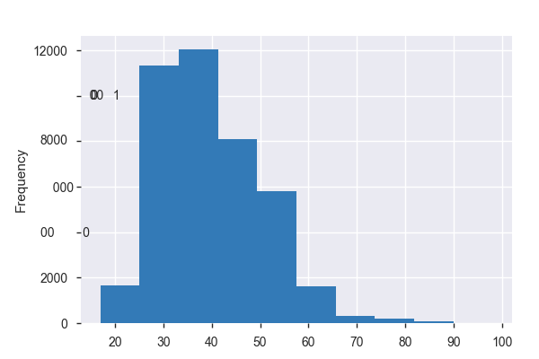

**Common Values**

| Value | Count | Frequency (%) |  |
| --- | --- | --- | --- |
| 31 | 1947 | 4.7% |  |
| 32 | 1846 | 4.5% |  |
| 33 | 1833 | 4.5% |  |
| 36 | 1780 | 4.3% |  |
| 35 | 1759 | 4.3% |  |
| 34 | 1745 | 4.2% |  |
| 30 | 1714 | 4.2% |  |
| 37 | 1475 | 3.6% |  |
| 29 | 1453 | 3.5% |  |
| 39 | 1432 | 3.5% |  |
| Other values (68) | 24204 | 58.8% |  |

**Extreme Values**

Minimum 5 values

| Value | Count | Frequency (%) |  |
| --- | --- | --- | --- |
| 17 | 5 | 0.0% |  |
| 18 | 28 | 0.1% |  |
| 19 | 42 | 0.1% |  |
| 20 | 65 | 0.2% |  |
| 21 | 102 | 0.2% |  |

Maximum 5 values

| Value | Count | Frequency (%) |  |
| --- | --- | --- | --- |
| 91 | 2 | 0.0% |  |
| 92 | 4 | 0.0% |  |
| 94 | 1 | 0.0% |  |
| 95 | 1 | 0.0% |  |
| 98 | 2 | 0.0% |  |

age_bracket  
Categorical

| Distinct count | 4 |
| --- | --- |
| Unique (%) | 0.0% |
| Missing (%) | 0.0% |
| Missing (n) | 0 |

| 1 | 19768 |
| --- | --- |
| 2 | 19188 |
| 3 | 2041 |

Toggle details

| Value | Count | Frequency (%) |  |
| --- | --- | --- | --- |
| 1 | 19768 | 48.0% |  |
| 2 | 19188 | 46.6% |  |
| 3 | 2041 | 5.0% |  |
| 4 | 191 | 0.5% |  |

campaign  
Numeric

| Distinct count | 42 |
| --- | --- |
| Unique (%) | 0.1% |
| Missing (%) | 0.0% |
| Missing (n) | 0 |
| Infinite (%) | 0.0% |
| Infinite (n) | 0 |

| Mean | 2.5676 |
| --- | --- |
| Minimum | 1 |
| Maximum | 56 |
| Zeros (%) | 0.0% |

Toggle details

**Statistics**

Quantile statistics

| Minimum | 1 |
| --- | --- |
| 5-th percentile | 1 |
| Q1 | 1 |
| Median | 2 |
| Q3 | 3 |
| 95-th percentile | 7 |
| Maximum | 56 |
| Range | 55 |
| Interquartile range | 2 |

Descriptive statistics

| Standard deviation | 2.77 |
| --- | --- |
| Coef of variation | 1.0788 |
| Kurtosis | 36.98 |
| Mean | 2.5676 |
| MAD | 1.6342 |
| Skewness | 4.7625 |
| Sum | 105754 |
| Variance | 7.673 |
| Memory size | 321.9 KiB |

**Histogram**

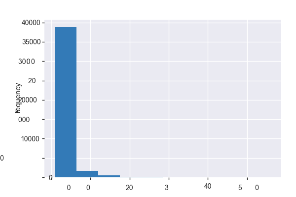

**Common Values**

| Value | Count | Frequency (%) |  |
| --- | --- | --- | --- |
| 1 | 17642 | 42.8% |  |
| 2 | 10570 | 25.7% |  |
| 3 | 5341 | 13.0% |  |
| 4 | 2651 | 6.4% |  |
| 5 | 1599 | 3.9% |  |
| 6 | 979 | 2.4% |  |
| 7 | 629 | 1.5% |  |
| 8 | 400 | 1.0% |  |
| 9 | 283 | 0.7% |  |
| 10 | 225 | 0.5% |  |
| Other values (32) | 869 | 2.1% |  |

**Extreme Values**

Minimum 5 values

| Value | Count | Frequency (%) |  |
| --- | --- | --- | --- |
| 1 | 17642 | 42.8% |  |
| 2 | 10570 | 25.7% |  |
| 3 | 5341 | 13.0% |  |
| 4 | 2651 | 6.4% |  |
| 5 | 1599 | 3.9% |  |

Maximum 5 values

| Value | Count | Frequency (%) |  |
| --- | --- | --- | --- |
| 40 | 2 | 0.0% |  |
| 41 | 1 | 0.0% |  |
| 42 | 2 | 0.0% |  |
| 43 | 2 | 0.0% |  |
| 56 | 1 | 0.0% |  |

cons.conf.idx  
Numeric

| Distinct count | 26 |
| --- | --- |
| Unique (%) | 0.1% |
| Missing (%) | 0.0% |
| Missing (n) | 0 |
| Infinite (%) | 0.0% |
| Infinite (n) | 0 |

| Mean | -40.503 |
| --- | --- |
| Minimum | -50.8 |
| Maximum | -26.9 |
| Zeros (%) | 0.0% |

Toggle details

**Statistics**

Quantile statistics

| Minimum | -50.8 |
| --- | --- |
| 5-th percentile | -47.1 |
| Q1 | -42.7 |
| Median | -41.8 |
| Q3 | -36.4 |
| 95-th percentile | -33.6 |
| Maximum | -26.9 |
| Range | 23.9 |
| Interquartile range | 6.3 |

Descriptive statistics

| Standard deviation | 4.6282 |
| --- | --- |
| Coef of variation | -0.11427 |
| Kurtosis | -0.35856 |
| Mean | -40.503 |
| MAD | 3.9383 |
| Skewness | 0.30318 |
| Sum | -1668200 |
| Variance | 21.42 |
| Memory size | 321.9 KiB |

**Histogram**

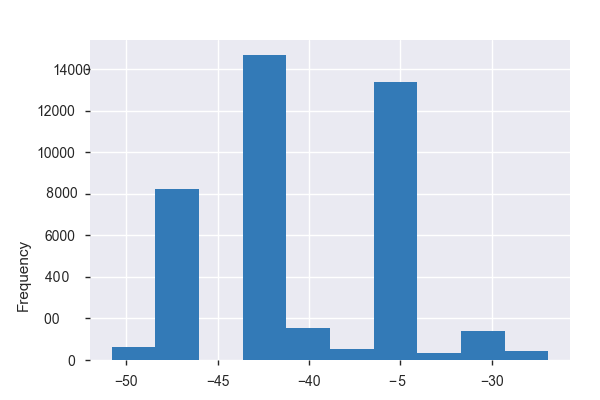

**Common Values**

| Value | Count | Frequency (%) |  |
| --- | --- | --- | --- |
| -36.4 | 7763 | 18.8% |  |
| -42.7 | 6685 | 16.2% |  |
| -46.2 | 5794 | 14.1% |  |
| -36.1 | 5175 | 12.6% |  |
| -41.8 | 4374 | 10.6% |  |
| -42.0 | 3616 | 8.8% |  |
| -47.1 | 2458 | 6.0% |  |
| -31.4 | 770 | 1.9% |  |
| -40.8 | 715 | 1.7% |  |
| -26.9 | 447 | 1.1% |  |
| Other values (16) | 3391 | 8.2% |  |

**Extreme Values**

Minimum 5 values

| Value | Count | Frequency (%) |  |
| --- | --- | --- | --- |
| -50.8 | 128 | 0.3% |  |
| -50.0 | 282 | 0.7% |  |
| -49.5 | 204 | 0.5% |  |
| -47.1 | 2458 | 6.0% |  |
| -46.2 | 5794 | 14.1% |  |

Maximum 5 values

| Value | Count | Frequency (%) |  |
| --- | --- | --- | --- |
| -33.0 | 172 | 0.4% |  |
| -31.4 | 770 | 1.9% |  |
| -30.1 | 357 | 0.9% |  |
| -29.8 | 267 | 0.6% |  |
| -26.9 | 447 | 1.1% |  |

cons.price.idx  
Numeric

| Distinct count | 26 |
| --- | --- |
| Unique (%) | 0.1% |
| Missing (%) | 0.0% |
| Missing (n) | 0 |
| Infinite (%) | 0.0% |
| Infinite (n) | 0 |

| Mean | 93.576 |
| --- | --- |
| Minimum | 92.201 |
| Maximum | 94.767 |
| Zeros (%) | 0.0% |

Toggle details

**Statistics**

Quantile statistics

| Minimum | 92.201 |
| --- | --- |
| 5-th percentile | 92.713 |
| Q1 | 93.075 |
| Median | 93.749 |
| Q3 | 93.994 |
| 95-th percentile | 94.465 |
| Maximum | 94.767 |
| Range | 2.566 |
| Interquartile range | 0.919 |

Descriptive statistics

| Standard deviation | 0.57884 |
| --- | --- |
| Coef of variation | 0.0061858 |
| Kurtosis | -0.82981 |
| Mean | 93.576 |
| MAD | 0.50981 |
| Skewness | -0.23089 |
| Sum | 3854200 |
| Variance | 0.33506 |
| Memory size | 321.9 KiB |

**Histogram**

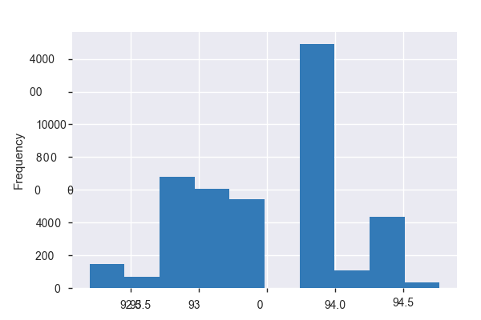

**Common Values**

| Value | Count | Frequency (%) |  |
| --- | --- | --- | --- |
| 93.994 | 7763 | 18.8% |  |
| 93.91799999999999 | 6685 | 16.2% |  |
| 92.89299999999999 | 5794 | 14.1% |  |
| 93.444 | 5175 | 12.6% |  |
| 94.465 | 4374 | 10.6% |  |
| 93.2 | 3616 | 8.8% |  |
| 93.075 | 2458 | 6.0% |  |
| 92.20100000000001 | 770 | 1.9% |  |
| 92.963 | 715 | 1.7% |  |
| 92.431 | 447 | 1.1% |  |
| Other values (16) | 3391 | 8.2% |  |

**Extreme Values**

Minimum 5 values

| Value | Count | Frequency (%) |  |
| --- | --- | --- | --- |
| 92.20100000000001 | 770 | 1.9% |  |
| 92.37899999999999 | 267 | 0.6% |  |
| 92.431 | 447 | 1.1% |  |
| 92.469 | 178 | 0.4% |  |
| 92.649 | 357 | 0.9% |  |

Maximum 5 values

| Value | Count | Frequency (%) |  |
| --- | --- | --- | --- |
| 94.199 | 303 | 0.7% |  |
| 94.215 | 311 | 0.8% |  |
| 94.465 | 4374 | 10.6% |  |
| 94.601 | 204 | 0.5% |  |
| 94.76700000000001 | 128 | 0.3% |  |

contact  
Categorical

| Distinct count | 2 |
| --- | --- |
| Unique (%) | 0.0% |
| Missing (%) | 0.0% |
| Missing (n) | 0 |

| cellular | 26144 |
| --- | --- |
| telephone | 15044 |

Toggle details

| Value | Count | Frequency (%) |  |
| --- | --- | --- | --- |
| cellular | 26144 | 63.5% |  |
| telephone | 15044 | 36.5% |  |

day_of_week  
Numeric

| Distinct count | 5 |
| --- | --- |
| Unique (%) | 0.0% |
| Missing (%) | 0.0% |
| Missing (n) | 0 |
| Infinite (%) | 0.0% |
| Infinite (n) | 0 |

| Mean | 1.9796 |
| --- | --- |
| Minimum | 0 |
| Maximum | 4 |
| Zeros (%) | 20.7% |

Toggle details

**Statistics**

Quantile statistics

| Minimum | 0 |
| --- | --- |
| 5-th percentile | 0 |
| Q1 | 1 |
| Median | 2 |
| Q3 | 3 |
| 95-th percentile | 4 |
| Maximum | 4 |
| Range | 4 |
| Interquartile range | 2 |

Descriptive statistics

| Standard deviation | 1.4115 |
| --- | --- |
| Coef of variation | 0.71304 |
| Kurtosis | -1.2998 |
| Mean | 1.9796 |
| MAD | 1.2032 |
| Skewness | 0.00055242 |
| Sum | 81535 |
| Variance | 1.9924 |
| Memory size | 321.9 KiB |

**Histogram**

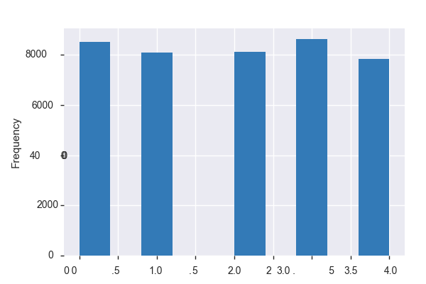

**Common Values**

| Value | Count | Frequency (%) |  |
| --- | --- | --- | --- |
| 3 | 8623 | 20.9% |  |
| 0 | 8514 | 20.7% |  |
| 2 | 8134 | 19.7% |  |
| 1 | 8090 | 19.6% |  |
| 4 | 7827 | 19.0% |  |

**Extreme Values**

Minimum 5 values

| Value | Count | Frequency (%) |  |
| --- | --- | --- | --- |
| 0 | 8514 | 20.7% |  |
| 1 | 8090 | 19.6% |  |
| 2 | 8134 | 19.7% |  |
| 3 | 8623 | 20.9% |  |
| 4 | 7827 | 19.0% |  |

Maximum 5 values

| Value | Count | Frequency (%) |  |
| --- | --- | --- | --- |
| 0 | 8514 | 20.7% |  |
| 1 | 8090 | 19.6% |  |
| 2 | 8134 | 19.7% |  |
| 3 | 8623 | 20.9% |  |
| 4 | 7827 | 19.0% |  |

default  
Boolean

| Distinct count | 2 |
| --- | --- |
| Unique (%) | 0.0% |
| Missing (%) | 0.0% |
| Missing (n) | 0 |

| Mean | 7.2837e-05 |
| --- | --- |

| 0 | 41185 |
| --- | --- |
| 1 | 3 |

Toggle details

| Value | Count | Frequency (%) |  |
| --- | --- | --- | --- |
| 0 | 41185 | 100.0% |  |
| 1 | 3 | 0.0% |  |

duration  
Numeric

| Distinct count | 1544 |
| --- | --- |
| Unique (%) | 3.7% |
| Missing (%) | 0.0% |
| Missing (n) | 0 |
| Infinite (%) | 0.0% |
| Infinite (n) | 0 |

| Mean | 258.29 |
| --- | --- |
| Minimum | 0 |
| Maximum | 4918 |
| Zeros (%) | 0.0% |

Toggle details

**Statistics**

Quantile statistics

| Minimum | 0 |
| --- | --- |
| 5-th percentile | 36 |
| Q1 | 102 |
| Median | 180 |
| Q3 | 319 |
| 95-th percentile | 752.65 |
| Maximum | 4918 |
| Range | 4918 |
| Interquartile range | 217 |

Descriptive statistics

| Standard deviation | 259.28 |
| --- | --- |
| Coef of variation | 1.0038 |
| Kurtosis | 20.248 |
| Mean | 258.29 |
| MAD | 171.67 |
| Skewness | 3.2631 |
| Sum | 10638243 |
| Variance | 67226 |
| Memory size | 321.9 KiB |

**Histogram**

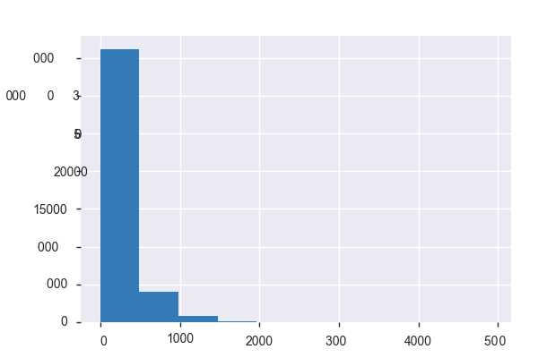

**Common Values**

| Value | Count | Frequency (%) |  |
| --- | --- | --- | --- |
| 85 | 170 | 0.4% |  |
| 90 | 170 | 0.4% |  |
| 136 | 168 | 0.4% |  |
| 73 | 167 | 0.4% |  |
| 124 | 164 | 0.4% |  |
| 87 | 162 | 0.4% |  |
| 72 | 161 | 0.4% |  |
| 104 | 161 | 0.4% |  |
| 111 | 160 | 0.4% |  |
| 106 | 159 | 0.4% |  |
| Other values (1534) | 39546 | 96.0% |  |

**Extreme Values**

Minimum 5 values

| Value | Count | Frequency (%) |  |
| --- | --- | --- | --- |
| 0 | 4 | 0.0% |  |
| 1 | 3 | 0.0% |  |
| 2 | 1 | 0.0% |  |
| 3 | 3 | 0.0% |  |
| 4 | 12 | 0.0% |  |

Maximum 5 values

| Value | Count | Frequency (%) |  |
| --- | --- | --- | --- |
| 3631 | 1 | 0.0% |  |
| 3643 | 1 | 0.0% |  |
| 3785 | 1 | 0.0% |  |
| 4199 | 1 | 0.0% |  |
| 4918 | 1 | 0.0% |  |

education  
Categorical

| Distinct count | 8 |
| --- | --- |
| Unique (%) | 0.0% |
| Missing (%) | 0.0% |
| Missing (n) | 0 |

| university.degree | 12168 |
| --- | --- |
| high.school | 9515 |
| basic.9y | 6045 |
| Other values (5) | 13460 |

Toggle details

| Value | Count | Frequency (%) |  |
| --- | --- | --- | --- |
| university.degree | 12168 | 29.5% |  |
| high.school | 9515 | 23.1% |  |
| basic.9y | 6045 | 14.7% |  |
| professional.course | 5243 | 12.7% |  |
| basic.4y | 4176 | 10.1% |  |
| basic.6y | 2292 | 5.6% |  |
| unknown | 1731 | 4.2% |  |
| illiterate | 18 | 0.0% |  |

emp.var.rate  
Numeric

| Distinct count | 10 |
| --- | --- |
| Unique (%) | 0.0% |
| Missing (%) | 0.0% |
| Missing (n) | 0 |
| Infinite (%) | 0.0% |
| Infinite (n) | 0 |

| Mean | 0.081886 |
| --- | --- |
| Minimum | -3.4 |
| Maximum | 1.4 |
| Zeros (%) | 0.0% |

Toggle details

**Statistics**

Quantile statistics

| Minimum | -3.4 |
| --- | --- |
| 5-th percentile | -2.9 |
| Q1 | -1.8 |
| Median | 1.1 |
| Q3 | 1.4 |
| 95-th percentile | 1.4 |
| Maximum | 1.4 |
| Range | 4.8 |
| Interquartile range | 3.2 |

Descriptive statistics

| Standard deviation | 1.571 |
| --- | --- |
| Coef of variation | 19.185 |
| Kurtosis | -1.0626 |
| Mean | 0.081886 |
| MAD | 1.4228 |
| Skewness | -0.7241 |
| Sum | 3372.7 |
| Variance | 2.4679 |
| Memory size | 321.9 KiB |

**Histogram**

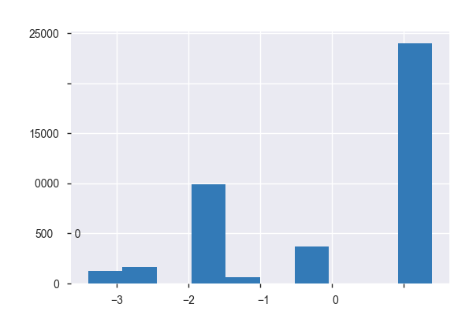

**Common Values**

| Value | Count | Frequency (%) |  |
| --- | --- | --- | --- |
| 1.4 | 16234 | 39.4% |  |
| -1.8 | 9184 | 22.3% |  |
| 1.1 | 7763 | 18.8% |  |
| -0.1 | 3683 | 8.9% |  |
| -2.9 | 1663 | 4.0% |  |
| -3.4 | 1071 | 2.6% |  |
| -1.7 | 773 | 1.9% |  |
| -1.1 | 635 | 1.5% |  |
| -3.0 | 172 | 0.4% |  |
| -0.2 | 10 | 0.0% |  |

**Extreme Values**

Minimum 5 values

| Value | Count | Frequency (%) |  |
| --- | --- | --- | --- |
| -3.4 | 1071 | 2.6% |  |
| -3.0 | 172 | 0.4% |  |
| -2.9 | 1663 | 4.0% |  |
| -1.8 | 9184 | 22.3% |  |
| -1.7 | 773 | 1.9% |  |

Maximum 5 values

| Value | Count | Frequency (%) |  |
| --- | --- | --- | --- |
| -1.1 | 635 | 1.5% |  |
| -0.2 | 10 | 0.0% |  |
| -0.1 | 3683 | 8.9% |  |
| 1.1 | 7763 | 18.8% |  |
| 1.4 | 16234 | 39.4% |  |

euribor3m  
Highly correlated

*This variable is highly correlated with `emp.var.rate` and should be ignored for analysis*

| Correlation | 0.97224 |
| --- | --- |

housing  
Boolean

| Distinct count | 2 |
| --- | --- |
| Unique (%) | 0.0% |
| Missing (%) | 0.0% |
| Missing (n) | 0 |

| Mean | 0.52384 |
| --- | --- |

| 1 | 21576 |
| --- | --- |
| 0 | 19612 |

Toggle details

| Value | Count | Frequency (%) |  |
| --- | --- | --- | --- |
| 1 | 21576 | 52.4% |  |
| 0 | 19612 | 47.6% |  |

job  
Categorical

| Distinct count | 12 |
| --- | --- |
| Unique (%) | 0.0% |
| Missing (%) | 0.0% |
| Missing (n) | 0 |

| admin. | 10422 |
| --- | --- |
| blue-collar | 9254 |
| technician | 6743 |
| Other values (9) | 14769 |

Toggle details

| Value | Count | Frequency (%) |  |
| --- | --- | --- | --- |
| admin. | 10422 | 25.3% |  |
| blue-collar | 9254 | 22.5% |  |
| technician | 6743 | 16.4% |  |
| services | 3969 | 9.6% |  |
| management | 2924 | 7.1% |  |
| retired | 1720 | 4.2% |  |
| entrepreneur | 1456 | 3.5% |  |
| self-employed | 1421 | 3.5% |  |
| housemaid | 1060 | 2.6% |  |
| unemployed | 1014 | 2.5% |  |
| Other values (2) | 1205 | 2.9% |  |

loan  
Boolean

| Distinct count | 2 |
| --- | --- |
| Unique (%) | 0.0% |
| Missing (%) | 0.0% |
| Missing (n) | 0 |

| Mean | 0.15169 |
| --- | --- |

| 0 | 34940 |
| --- | --- |
| 1 | 6248 |

Toggle details

| Value | Count | Frequency (%) |  |
| --- | --- | --- | --- |
| 0 | 34940 | 84.8% |  |
| 1 | 6248 | 15.2% |  |

marital  
Categorical

| Distinct count | 4 |
| --- | --- |
| Unique (%) | 0.0% |
| Missing (%) | 0.0% |
| Missing (n) | 0 |

| married | 24928 |
| --- | --- |
| single | 11568 |
| divorced | 4612 |

Toggle details

| Value | Count | Frequency (%) |  |
| --- | --- | --- | --- |
| married | 24928 | 60.5% |  |
| single | 11568 | 28.1% |  |
| divorced | 4612 | 11.2% |  |
| unknown | 80 | 0.2% |  |

month  
Numeric

| Distinct count | 10 |
| --- | --- |
| Unique (%) | 0.0% |
| Missing (%) | 0.0% |
| Missing (n) | 0 |
| Infinite (%) | 0.0% |
| Infinite (n) | 0 |

| Mean | 5.6079 |
| --- | --- |
| Minimum | 2 |
| Maximum | 11 |
| Zeros (%) | 0.0% |

Toggle details

**Statistics**

Quantile statistics

| Minimum | 2 |
| --- | --- |
| 5-th percentile | 3 |
| Q1 | 4 |
| Median | 5 |
| Q3 | 7 |
| 95-th percentile | 10 |
| Maximum | 11 |
| Range | 9 |
| Interquartile range | 3 |

Descriptive statistics

| Standard deviation | 2.041 |
| --- | --- |
| Coef of variation | 0.36395 |
| Kurtosis | -0.027876 |
| Mean | 5.6079 |
| MAD | 1.661 |
| Skewness | 0.85151 |
| Sum | 230978 |
| Variance | 4.1657 |
| Memory size | 321.9 KiB |

**Histogram**

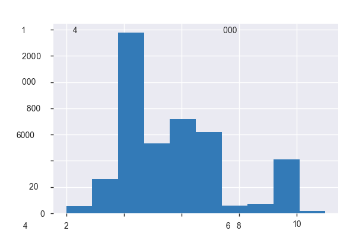

**Common Values**

| Value | Count | Frequency (%) |  |
| --- | --- | --- | --- |
| 4 | 13769 | 33.4% |  |
| 6 | 7174 | 17.4% |  |
| 7 | 6178 | 15.0% |  |
| 5 | 5318 | 12.9% |  |
| 10 | 4101 | 10.0% |  |
| 3 | 2632 | 6.4% |  |
| 9 | 718 | 1.7% |  |
| 8 | 570 | 1.4% |  |
| 2 | 546 | 1.3% |  |
| 11 | 182 | 0.4% |  |

**Extreme Values**

Minimum 5 values

| Value | Count | Frequency (%) |  |
| --- | --- | --- | --- |
| 2 | 546 | 1.3% |  |
| 3 | 2632 | 6.4% |  |
| 4 | 13769 | 33.4% |  |
| 5 | 5318 | 12.9% |  |
| 6 | 7174 | 17.4% |  |

Maximum 5 values

| Value | Count | Frequency (%) |  |
| --- | --- | --- | --- |
| 7 | 6178 | 15.0% |  |
| 8 | 570 | 1.4% |  |
| 9 | 718 | 1.7% |  |
| 10 | 4101 | 10.0% |  |
| 11 | 182 | 0.4% |  |

nr.employed  
Highly correlated

*This variable is highly correlated with `euribor3m` and should be ignored for analysis*

| Correlation | 0.94515 |
| --- | --- |

pdays  
Numeric

| Distinct count | 27 |
| --- | --- |
| Unique (%) | 0.1% |
| Missing (%) | 0.0% |
| Missing (n) | 0 |
| Infinite (%) | 0.0% |
| Infinite (n) | 0 |

| Mean | 962.48 |
| --- | --- |
| Minimum | 0 |
| Maximum | 999 |
| Zeros (%) | 0.0% |

Toggle details

**Statistics**

Quantile statistics

| Minimum | 0 |
| --- | --- |
| 5-th percentile | 999 |
| Q1 | 999 |
| Median | 999 |
| Q3 | 999 |
| 95-th percentile | 999 |
| Maximum | 999 |
| Range | 999 |
| Interquartile range | 0 |

Descriptive statistics

| Standard deviation | 186.91 |
| --- | --- |
| Coef of variation | 0.1942 |
| Kurtosis | 22.229 |
| Mean | 962.48 |
| MAD | 70.362 |
| Skewness | -4.9222 |
| Sum | 39642439 |
| Variance | 34936 |
| Memory size | 321.9 KiB |

**Histogram**

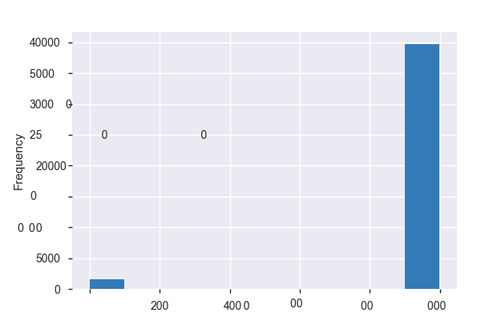

**Common Values**

| Value | Count | Frequency (%) |  |
| --- | --- | --- | --- |
| 999 | 39673 | 96.3% |  |
| 3 | 439 | 1.1% |  |
| 6 | 412 | 1.0% |  |
| 4 | 118 | 0.3% |  |
| 9 | 64 | 0.2% |  |
| 2 | 61 | 0.1% |  |
| 7 | 60 | 0.1% |  |
| 12 | 58 | 0.1% |  |
| 10 | 52 | 0.1% |  |
| 5 | 46 | 0.1% |  |
| Other values (17) | 205 | 0.5% |  |

**Extreme Values**

Minimum 5 values

| Value | Count | Frequency (%) |  |
| --- | --- | --- | --- |
| 0 | 15 | 0.0% |  |
| 1 | 26 | 0.1% |  |
| 2 | 61 | 0.1% |  |
| 3 | 439 | 1.1% |  |
| 4 | 118 | 0.3% |  |

Maximum 5 values

| Value | Count | Frequency (%) |  |
| --- | --- | --- | --- |
| 22 | 3 | 0.0% |  |
| 25 | 1 | 0.0% |  |
| 26 | 1 | 0.0% |  |
| 27 | 1 | 0.0% |  |
| 999 | 39673 | 96.3% |  |

poutcome  
Numeric

| Distinct count | 3 |
| --- | --- |
| Unique (%) | 0.0% |
| Missing (%) | 86.3% |
| Missing (n) | 35563 |
| Infinite (%) | 0.0% |
| Infinite (n) | 0 |

| Mean | 0.24409 |
| --- | --- |
| Minimum | 0 |
| Maximum | 1 |
| Zeros (%) | 10.3% |

Toggle details

**Statistics**

Quantile statistics

| Minimum | 0 |
| --- | --- |
| 5-th percentile | 0 |
| Q1 | 0 |
| Median | 0 |
| Q3 | 0 |
| 95-th percentile | 1 |
| Maximum | 1 |
| Range | 1 |
| Interquartile range | 0 |

Descriptive statistics

| Standard deviation | 0.42958 |
| --- | --- |
| Coef of variation | 1.7599 |
| Kurtosis | -0.57967 |
| Mean | 0.24409 |
| MAD | 0.36902 |
| Skewness | 1.1919 |
| Sum | 1373 |
| Variance | 0.18454 |
| Memory size | 321.9 KiB |

**Histogram**

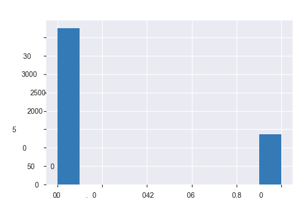

**Common Values**

| Value | Count | Frequency (%) |  |
| --- | --- | --- | --- |
| 0.0 | 4252 | 10.3% |  |
| 1.0 | 1373 | 3.3% |  |
| (Missing) | 35563 | 86.3% |  |

**Extreme Values**

Minimum 5 values

| Value | Count | Frequency (%) |  |
| --- | --- | --- | --- |
| 0.0 | 4252 | 10.3% |  |
| 1.0 | 1373 | 3.3% |  |

Maximum 5 values

| Value | Count | Frequency (%) |  |
| --- | --- | --- | --- |
| 0.0 | 4252 | 10.3% |  |
| 1.0 | 1373 | 3.3% |  |

previous  
Numeric

| Distinct count | 8 |
| --- | --- |
| Unique (%) | 0.0% |
| Missing (%) | 0.0% |
| Missing (n) | 0 |
| Infinite (%) | 0.0% |
| Infinite (n) | 0 |

| Mean | 0.17296 |
| --- | --- |
| Minimum | 0 |
| Maximum | 7 |
| Zeros (%) | 86.3% |

Toggle details

**Statistics**

Quantile statistics

| Minimum | 0 |
| --- | --- |
| 5-th percentile | 0 |
| Q1 | 0 |
| Median | 0 |
| Q3 | 0 |
| 95-th percentile | 1 |
| Maximum | 7 |
| Range | 7 |
| Interquartile range | 0 |

Descriptive statistics

| Standard deviation | 0.4949 |
| --- | --- |
| Coef of variation | 2.8613 |
| Kurtosis | 20.109 |
| Mean | 0.17296 |
| MAD | 0.29868 |
| Skewness | 3.832 |
| Sum | 7124 |
| Variance | 0.24493 |
| Memory size | 321.9 KiB |

**Histogram**

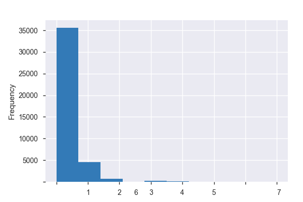

**Common Values**

| Value | Count | Frequency (%) |  |
| --- | --- | --- | --- |
| 0 | 35563 | 86.3% |  |
| 1 | 4561 | 11.1% |  |
| 2 | 754 | 1.8% |  |
| 3 | 216 | 0.5% |  |
| 4 | 70 | 0.2% |  |
| 5 | 18 | 0.0% |  |
| 6 | 5 | 0.0% |  |
| 7 | 1 | 0.0% |  |

**Extreme Values**

Minimum 5 values

| Value | Count | Frequency (%) |  |
| --- | --- | --- | --- |
| 0 | 35563 | 86.3% |  |
| 1 | 4561 | 11.1% |  |
| 2 | 754 | 1.8% |  |
| 3 | 216 | 0.5% |  |
| 4 | 70 | 0.2% |  |

Maximum 5 values

| Value | Count | Frequency (%) |  |
| --- | --- | --- | --- |
| 3 | 216 | 0.5% |  |
| 4 | 70 | 0.2% |  |
| 5 | 18 | 0.0% |  |
| 6 | 5 | 0.0% |  |
| 7 | 1 | 0.0% |  |

y  
Boolean

| Distinct count | 2 |
| --- | --- |
| Unique (%) | 0.0% |
| Missing (%) | 0.0% |
| Missing (n) | 0 |

| Mean | 0.11265 |
| --- | --- |

| 0 | 36548 |
| --- | --- |
| 1 | 4640 |

Toggle details

| Value | Count | Frequency (%) |  |
| --- | --- | --- | --- |
| 0 | 36548 | 88.7% |  |
| 1 | 4640 | 11.3% |  |

# Sample

|  | age | job | marital | education | default | housing | loan | contact | month | day_of_week | duration | campaign | pdays | previous | poutcome | emp.var.rate | cons.price.idx | cons.conf.idx | euribor3m | nr.employed | y | age_bracket |
| --- | --- | --- | --- | --- | --- | --- | --- | --- | --- | --- | --- | --- | --- | --- | --- | --- | --- | --- | --- | --- | --- | --- |
| 0 | 56 | housemaid | married | basic.4y | 0 | 0 | 0 | telephone | 4 | 0 | 261 | 1 | 999 | 0 | NaN | 1.1 | 93.994 | -36.4 | 4.857 | 5191.0 | 0 | 2 |
| 1 | 57 | services | married | high.school | 0 | 0 | 0 | telephone | 4 | 0 | 149 | 1 | 999 | 0 | NaN | 1.1 | 93.994 | -36.4 | 4.857 | 5191.0 | 0 | 2 |
| 2 | 37 | services | married | high.school | 0 | 1 | 0 | telephone | 4 | 0 | 226 | 1 | 999 | 0 | NaN | 1.1 | 93.994 | -36.4 | 4.857 | 5191.0 | 0 | 1 |
| 3 | 40 | admin. | married | basic.6y | 0 | 0 | 0 | telephone | 4 | 0 | 151 | 1 | 999 | 0 | NaN | 1.1 | 93.994 | -36.4 | 4.857 | 5191.0 | 0 | 2 |
| 4 | 56 | services | married | high.school | 0 | 0 | 1 | telephone | 4 | 0 | 307 | 1 | 999 | 0 | NaN | 1.1 | 93.994 | -36.4 | 4.857 | 5191.0 | 0 | 2 |